# Ordinal Logistic Regression DrPH Sem 2

Author

Dr Hazlienor Mohd Hatta

Published

July 1, 2024

# Ordinal Logistic Regression

## Research question

A study looks at factors that influence the decision of whether to apply to graduate school. College juniors are asked if they are unlikely, somewhat likely, or very likely to apply to graduate school. Hence, our outcome variable has three categories. Data on parental educational status, whether the undergraduate institution is public or private, and current GPA is also collected. The researchers have reason to believe that the “distances” between these three points are not equal. For example, the “distance” between “unlikely” and “somewhat likely” may be shorter than the distance between “somewhat likely” and “very likely”.

## Justification

1. outcome is categorical
2. outcome is more than 2 categories or levels
3. outcome is ordinal.
4. the order or rank of the outcome is important to the analysts

   multinomial does not address the ordinal of outcomes

## Model

1. adjacent-category logit model
   - log odds of an observation being in one category versus an adjacent category.
   - the log-odds does not depend on the response
   - the log-odds is linear in the coefficients
   - Used when interest is in the odds of being in one category versus the next higher category.
   - Common in studies where natural ordering of the categories is of primary importance.

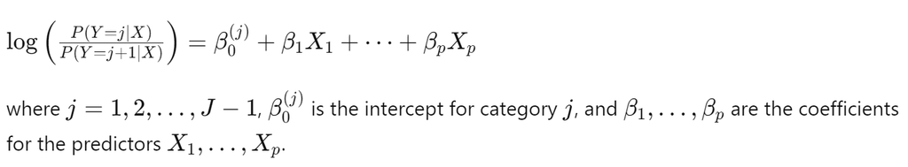

2. continuation-ratio logit model
   - In the continuation-ratio logistic model, we compare each response to ALL LOWER responses that is 𝑌=𝑘 versus 𝑌<𝑘. have different constant terms and different slopes for each logit.
   - Often used in survival analysis or settings where the progression through categories is sequential, such as educational attainment or disease stages.

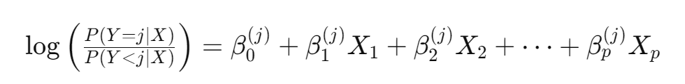

3. the proportional odds model (also known as the cumulative logit model).
   - the log-odds do not depend on the outcome category.
   - assumes the effect of the predictors is the same for all cumulative logit comparisons (proportional odds assumption).
   - if there are 𝐺 outcome categories, there is only one parameter (𝛽) for each of the predictors variables (e.g., 𝛽1 for predictor 𝑋1). However, there is still a separate intercept term (𝛼𝑔) for each of the 𝐺−1 comparisons.
   - Widely used for ordinal outcomes with natural ordering, such as Likert scales or disease severity scores.

   log odds (linear predictor)

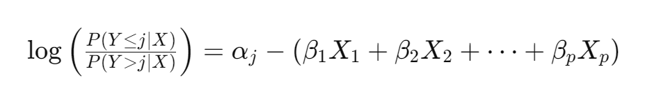

   the probability that the disease outcome is in a category greater than or equal to𝑔 given the exposure

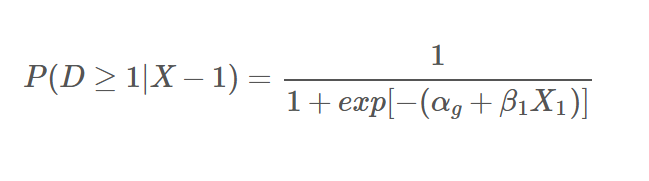

   The probability that the disease outcome is in a category less than 𝑔 is equal to 1 minus the probability that the disease outcome is greater than or equal to category 𝑔.

## Prepare environment

```r
library(haven) # read data
library(tidyverse) # data manipulation
```

```
✖ purrr::%||%()   masks base::%||%()
```

```r
library(gtsummary) # data tabulation
library(ordinal) # ordinal regression
library(broom)
```

## Dataset

This hypothetical data set has a three level variable called **`apply`**, with levels “unlikely”, “somewhat likely”, and “very likely”, coded 1, 2, and 3, respectively, that we will use as our outcome variable. We also have three variables that we will use as predictors: **`pared`**, which is a 0/1 variable indicating whether at least one parent has a graduate degree; **`public`**, which is a 0/1 variable where 1 indicates that the undergraduate institution is public and 0 private, and **`gpa`**, which is the student’s grade point average. Let’s start with the descriptive statistics of these variables.

### Load data

```r
college <- read_dta("https://stats.idre.ucla.edu/stat/data/ologit.dta")
```

### Data exploration

```r
str(college)
```

```
tibble [400 × 4] (S3: tbl_df/tbl/data.frame)
 $ apply : dbl+lbl [1:400] 2, 1, 0, 1, 1, 0, 1, 1, 0, 1, 0, 1, 2, 1, 0, 0, 0, 0, ...
   ..@ format.stata: chr "%15.0g"
   ..@ labels      : Named num [1:3] 0 1 2
   .. ..- attr(*, "names")= chr [1:3] "unlikely" "somewhat likely" "very likely"
 $ pared : num [1:400] 0 1 1 0 0 0 0 0 0 1 ...
  ..- attr(*, "format.stata")= chr "%9.0g"
 $ public: num [1:400] 0 0 1 0 0 1 0 0 0 0 ...
  ..- attr(*, "format.stata")= chr "%9.0g"
 $ gpa   : num [1:400] 3.26 3.21 3.94 2.81 2.53 ...
  ..- attr(*, "format.stata")= chr "%9.0g"
```

### Data wrangling

```r
college <- college %>%
  mutate(across(where(~ is.labelled(.x)), as_factor)) %>%
  mutate(pared = as.factor(pared), public = as.factor(public))
```

```r
summary(college)
```

```
             apply     pared   public       gpa
 unlikely       :220   0:337   0:343   Min.   :1.900
 somewhat likely:140   1: 63   1: 57   1st Qu.:2.720
 very likely    : 40                   Median :2.990
                                       Mean   :2.999
                                       3rd Qu.:3.270
                                       Max.   :4.000
```

## Descriptive analysis

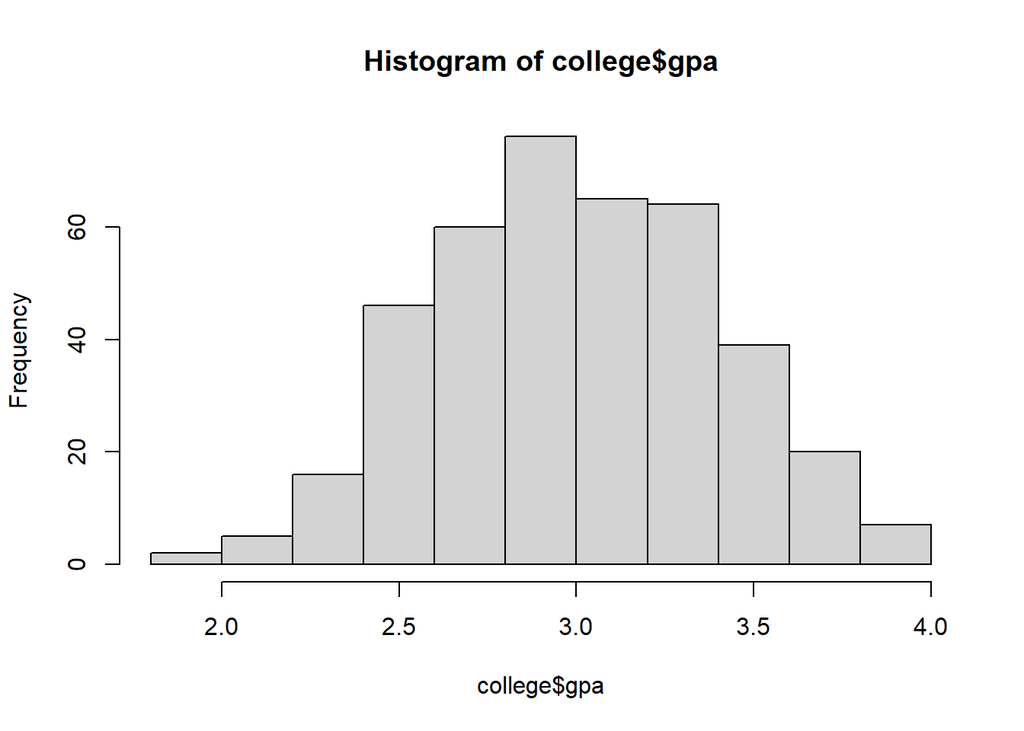

```r
hist(college$gpa)
```

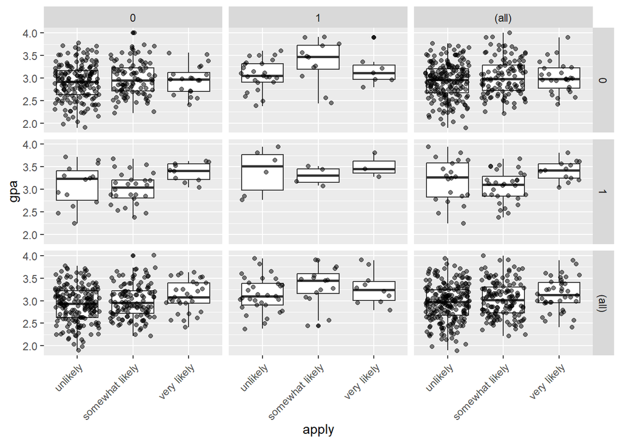

```r
ggplot(college, aes(x = apply, y = gpa)) +
  geom_boxplot(size = .5) +
  geom_jitter(alpha = .5) +
  facet_grid(pared ~ public, margins = TRUE) +
  theme(axis.text.x = element_text(angle = 45, hjust = 1, vjust = 1))
```

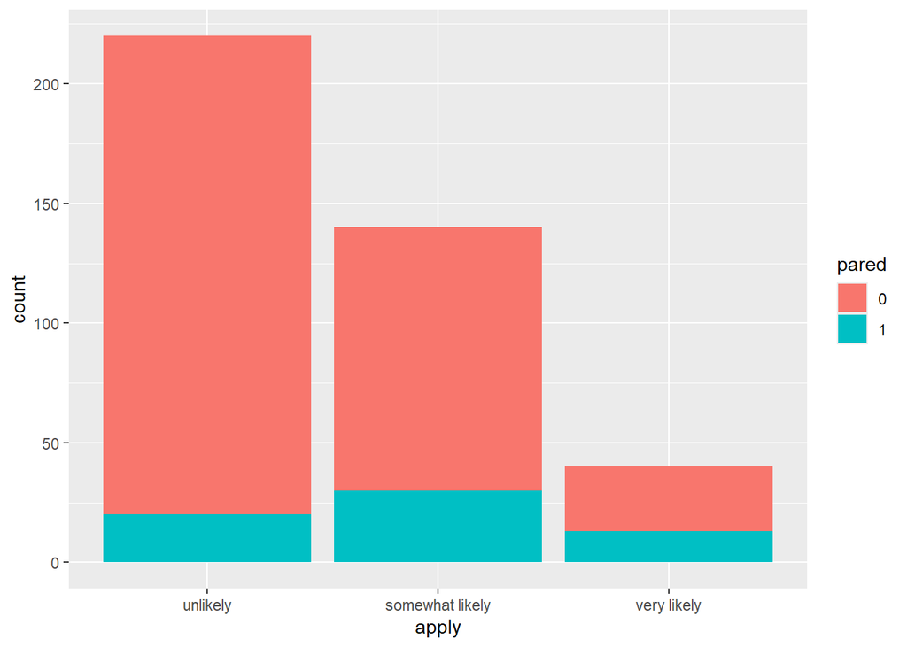

```r
ggplot(college, aes(x = apply, fill = pared)) +
  geom_bar()
```

```r
college %>% tbl_summary(by = apply,
              statistic = list(all_continuous() ~ "{mean} ({sd})"))
```

| **Characteristic** | **unlikely**, N = 220<sup>1</sup> | **somewhat likely**, N = 140<sup>1</sup> | **very likely**, N = 40<sup>1</sup> |
| --- | --- | --- | --- |
| pared |  |  |  |
| 0 | 200 (91%) | 110 (79%) | 27 (68%) |
| 1 | 20 (9.1%) | 30 (21%) | 13 (33%) |
| public |  |  |  |
| 0 | 189 (86%) | 124 (89%) | 30 (75%) |
| 1 | 31 (14%) | 16 (11%) | 10 (25%) |
| gpa | 2.95 (0.40) | 3.03 (0.39) | 3.15 (0.36) |

<sup>1</sup> n (%); Mean (SD)

## Ordinal Regression Analysis

Proportional odds model/cumulative logit model

### Estimate

```r
ord1 <- clm(apply ~ pared + public + gpa, data = college)
summary(ord1)
```

```
formula: apply ~ pared + public + gpa
data:    college

 link  threshold nobs logLik  AIC    niter max.grad cond.H
 logit flexible  400  -358.51 727.02 5(0)  1.63e-10 1.3e+03

Coefficients:
        Estimate Std. Error z value Pr(>|z|)
pared1   1.04766    0.26579   3.942 8.09e-05 ***
public1 -0.05868    0.29786  -0.197   0.8438
gpa      0.61575    0.26063   2.363   0.0182 *
---
Signif. codes:  0 '***' 0.001 '**' 0.01 '*' 0.05 '.' 0.1 ' ' 1

Threshold coefficients:
                            Estimate Std. Error z value
unlikely|somewhat likely      2.2033     0.7795   2.826
somewhat likely|very likely   4.2988     0.8043   5.345
```

log odds

```r
tidy(ord1)
```

```
# A tibble: 5 × 6
  term                        estimate std.error statistic     p.value coef.type
  <chr>                          <dbl>     <dbl>     <dbl>       <dbl> <chr>
1 unlikely|somewhat likely      2.20       0.780     2.83      4.71e-3 intercept
2 somewhat likely|very likely   4.30       0.804     5.34      9.06e-8 intercept
3 pared1                        1.05       0.266     3.94      8.09e-5 location
4 public1                      -0.0587     0.298    -0.197     8.44e-1 location
5 gpa                           0.616      0.261     2.36      1.82e-2 location
```

odds

```r
tidy(ord1, exponentiate =T)
```

```
# A tibble: 5 × 6
  term                        estimate std.error statistic     p.value coef.type
  <chr>                          <dbl>     <dbl>     <dbl>       <dbl> <chr>
1 unlikely|somewhat likely       9.06      0.780     2.83      4.71e-3 intercept
2 somewhat likely|very likely   73.6       0.804     5.34      9.06e-8 intercept
3 pared1                         2.85      0.266     3.94      8.09e-5 location
4 public1                        0.943     0.298    -0.197     8.44e-1 location
5 gpa                            1.85      0.261     2.36      1.82e-2 location
```

### Inference

```r
tidy(ord1, conf.int =T)
```

```
# A tibble: 5 × 8
  term         estimate std.error statistic p.value conf.low conf.high coef.type
  <chr>           <dbl>     <dbl>     <dbl>   <dbl>    <dbl>     <dbl> <chr>
1 unlikely|so…   2.20       0.780     2.83  4.71e-3   NA        NA     intercept
2 somewhat li…   4.30       0.804     5.34  9.06e-8   NA        NA     intercept
3 pared1         1.05       0.266     3.94  8.09e-5    0.528     1.57  location
4 public1       -0.0587     0.298    -0.197 8.44e-1   -0.652     0.519 location
5 gpa            0.616      0.261     2.36  1.82e-2    0.108     1.13  location
```

### Simple model

```r
ord2 <- clm(apply ~ public, data = college)
summary(ord2)
```

```
formula: apply ~ public
data:    college

 link  threshold nobs logLik  AIC    niter max.grad cond.H
 logit flexible  400  -370.40 746.79 5(0)  2.76e-11 1.1e+01

Coefficients:
        Estimate Std. Error z value Pr(>|z|)
public1   0.1833     0.2838   0.646    0.518

Threshold coefficients:
                            Estimate Std. Error z value
unlikely|somewhat likely      0.2252     0.1076   2.092
somewhat likely|very likely   2.2231     0.1718  12.943
```

### Compare model

```r
anova(ord1, ord2, test = 'Chisq')
```

```
'test' argument ignored in anova.clm
```

```
Likelihood ratio tests of cumulative link models:

     formula:                     link: threshold:
ord2 apply ~ public               logit flexible
ord1 apply ~ pared + public + gpa logit flexible

     no.par    AIC  logLik LR.stat df Pr(>Chisq)
ord2      3 746.79 -370.40
ord1      5 727.02 -358.51  23.766  2  6.906e-06 ***
---
Signif. codes:  0 '***' 0.001 '**' 0.01 '*' 0.05 '.' 0.1 ' ' 1
```

the more complex model (**ord1)** has higher (less negative) log likelihood and lower AIC. Likelihood ratio test indicate that the improvement in model fit by adding more variables in **ord1** is statistically significant (p-value <0.05). Given the significant p-value, we would reject the null hypothesis that the simpler model (**ord2**) is sufficient and prefer the more complex model (**ord1**).

## Prediction

omit outcome variable to create a new dataset

```r
college1<-
  college %>%
  select(-apply)
prob.ord1 <- predict(ord1, newdata = college1)
head(prob.ord1$fit) ; tail(prob.ord1$fit)
```

```
   unlikely somewhat likely very likely
1 0.5488417       0.3593236  0.09183471
2 0.3055759       0.4759464  0.21847772
3 0.2294011       0.4781972  0.29240171
4 0.6161119       0.3126961  0.07119199
5 0.6559926       0.2834065  0.06060091
6 0.6608814       0.2797435  0.05937515
```

```
     unlikely somewhat likely very likely
395 0.2642333       0.4806228  0.25514386
396 0.4812747       0.4016588  0.11706649
397 0.6419670       0.2938304  0.06420257
398 0.6937894       0.2547126  0.05149808
399 0.5488417       0.3593236  0.09183471
400 0.5089735       0.3849388  0.10608765
```

bind prediction to data

```r
collegepp <-cbind(college, prob.ord1)
```

predict class

```r
class.ord1 <- predict(ord1, type = 'class')
head(class.ord1)
```

```
$fit
  [1] unlikely        somewhat likely somewhat likely unlikely
  [5] unlikely        unlikely        unlikely        unlikely
  [9] unlikely        somewhat likely somewhat likely unlikely
 [13] unlikely        unlikely        somewhat likely unlikely
 [17] unlikely        unlikely        unlikely        unlikely
 [21] unlikely        somewhat likely unlikely        unlikely
 [25] unlikely        unlikely        somewhat likely unlikely
 [29] unlikely        unlikely        unlikely        unlikely
 [33] unlikely        somewhat likely unlikely        unlikely
 [37] unlikely        unlikely        unlikely        unlikely
 [41] unlikely        somewhat likely unlikely        unlikely
 [45] somewhat likely unlikely        unlikely        unlikely
 [49] unlikely        unlikely        unlikely        unlikely
 [53] unlikely        unlikely        unlikely        unlikely
```

[output cut: 87 more lines]

### Manual calculation for prediction

Predict probability

```r
head(college1)
```

```
# A tibble: 6 × 3
  pared public   gpa
  <fct> <fct>  <dbl>
1 0     0       3.26
2 1     0       3.21
3 1     1       3.94
4 0     0       2.81
5 0     0       2.53
6 0     1       2.59
```

extract coef from model

```r
coef(ord1)
```

```
   unlikely|somewhat likely somewhat likely|very likely
                 2.20332325                  4.29876741
                     pared1                     public1
                 1.04766366                 -0.05868279
                        gpa
                 0.61574582
```

```r
lp.ord1 <- predict(ord1, newdata = college1, type = 'linear.predictor')
lp.ord1[1]
```

```
$eta1
        unlikely somewhat likely very likely
1    0.195991872       2.2914360    99997.99
2   -0.820884529       1.2745596    99996.98
3   -1.211696205       0.8837480    99996.58
4    0.473077522       2.5685217    99998.27
5    0.645486335       2.7409305    99998.44
6    0.667224408       2.7626686    99998.46
7    0.627013978       2.7224581    99998.42
8    0.522337141       2.6177813    99998.32
9    0.356085780       2.4515299    99998.15
10  -0.999450795       1.0959934    99996.80
11  -1.033129939       1.0623142    99996.76
12   0.454605165       2.5500493    99998.25
13  -0.139402732       1.9560414    99997.66
```

[output cut: 387 more lines]

1st observation

```r
college1[1,]
```

```
# A tibble: 1 × 3
  pared public   gpa
  <fct> <fct>  <dbl>
1 0     0       3.26
```

log odd for 1st observation unlikely (<=1)/somewhat likely + very likely(>1)

```r
2.20332325 - ((4.29876741*0)+(-0.05868279*0)+(0.61574582*3.26))
```

```
[1] 0.1959919
```

log odd for 1st observation unlikely+somewhat likely (<=2)/very likely(>2)

```r
4.29876741 - ((4.29876741*0)+(-0.05868279*0)+(0.61574582*3.26))
```

```
[1] 2.291436
```

probability

```r
predict(ord1, newdata = college1, type = 'prob')
```

```
$fit
     unlikely somewhat likely very likely
1   0.5488417       0.3593236  0.09183471
2   0.3055759       0.4759464  0.21847772
3   0.2294011       0.4781972  0.29240171
4   0.6161119       0.3126961  0.07119199
5   0.6559926       0.2834065  0.06060091
6   0.6608814       0.2797435  0.05937515
7   0.6518121       0.2865268  0.06166109
8   0.6276941       0.3043031  0.06800278
9   0.5880926       0.3325807  0.07932674
10  0.2690494       0.4804592  0.25049137
11  0.2624778       0.4806548  0.25686745
12  0.6117336       0.3158432  0.07242317
13  0.4652056       0.4108983  0.12389609
```

[output cut: 387 more lines]

1=unlikely

2= somewhat likely

3= very likely

probability unlikely 1st observation ( <=1)

```r
exp(0.1959919)/(1+exp(0.1959919))
```

```
[1] 0.5488417
```

OR probability unlikely 1st observation (<=1)

```r
1/(1+exp(-0.1959919))
```

```
[1] 0.5488417
```

probability somewhat likely+very likely (>=2)

```r
exp(-0.1959919)/(1+exp(-0.1959919))
```

```
[1] 0.4511583
```

or

```r
1-(exp(0.1959919)/(1+exp(0.1959919)))
```

```
[1] 0.4511583
```

probability unlikely+somewhat likely 1st observation (<=2)

```r
1/(1+exp(-2.291436))
```

```
[1] 0.9081653
```

```r
0.5488417+0.3593236
```

```
[1] 0.9081653
```

## Model checking

proportional odd assumption for numerical variable

```r
nominal_test(ord1)
```

```
Tests of nominal effects

formula: apply ~ pared + public + gpa
       Df  logLik    AIC    LRT Pr(>Chi)
<none>    -358.51 727.02
pared   1 -358.50 729.00 0.0247  0.87510
public  1 -356.57 725.14 3.8833  0.04877 *
gpa     1 -358.11 728.22 0.8016  0.37061
---
Signif. codes:  0 '***' 0.001 '**' 0.01 '*' 0.05 '.' 0.1 ' ' 1
```

gpa >0.05, proportional odd assumption cant be rejected

another method

```r
ord.gpa <- clm(apply ~ pared + public, nominal = ~gpa, data = college)
```

```r
anova(ord1, ord.gpa)
```

```
Likelihood ratio tests of cumulative link models:

        formula:                     nominal: link: threshold:
ord1    apply ~ pared + public + gpa ~1       logit flexible
ord.gpa apply ~ pared + public       ~gpa     logit flexible

        no.par    AIC  logLik LR.stat df Pr(>Chisq)
ord1         5 727.02 -358.51
ord.gpa      6 728.22 -358.11  0.8016  1     0.3706
```

The p-value is not significant at 5% level, hence the proportionality does present for variable gpa.

## **Interpretation**

```r
summary(ord1)
```

```
formula: apply ~ pared + public + gpa
data:    college

 link  threshold nobs logLik  AIC    niter max.grad cond.H
 logit flexible  400  -358.51 727.02 5(0)  1.63e-10 1.3e+03

Coefficients:
        Estimate Std. Error z value Pr(>|z|)
pared1   1.04766    0.26579   3.942 8.09e-05 ***
public1 -0.05868    0.29786  -0.197   0.8438
gpa      0.61575    0.26063   2.363   0.0182 *
---
Signif. codes:  0 '***' 0.001 '**' 0.01 '*' 0.05 '.' 0.1 ' ' 1

Threshold coefficients:
                            Estimate Std. Error z value
unlikely|somewhat likely      2.2033     0.7795   2.826
somewhat likely|very likely   4.2988     0.8043   5.345
```

```r
lo_ord1 <-tidy(ord1, conf.int=T)
lo_ord1<- lo_ord1 %>% select(term, estimate, conf.low, conf.high)
odd_ord1 <-tidy(ord1, exponentiate=T, conf.int=T)
odd_ord1<- odd_ord1 %>% select(estimate, conf.low, conf.high, p.value)
cbind(lo_ord1, odd_ord1)
```

```
                         term    estimate   conf.low conf.high   estimate
1    unlikely|somewhat likely  2.20332325         NA        NA  9.0550558
2 somewhat likely|very likely  4.29876741         NA        NA 73.6090082
3                      pared1  1.04766366  0.5281776 1.5721696  2.8509825
4                     public1 -0.05868279 -0.6521908 0.5191405  0.9430059
5                         gpa  0.61574582  0.1076197 1.1309092  1.8510366
   conf.low conf.high      p.value
1        NA        NA 4.706602e-03
2        NA        NA 9.060004e-08
3 1.6958390  4.817088 8.090273e-05
4 0.5209033  1.680583 8.438155e-01
5 1.1136241  3.098472 1.815123e-02
```

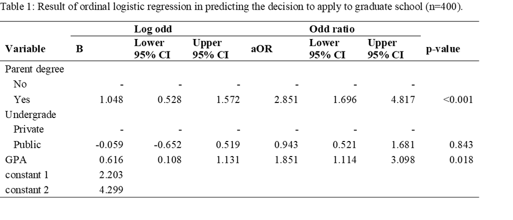

The odds of being in a higher category (vs lower) of decision to apply to graduate school are approximately 2.85 (95% CI: 1.70, 4.82, p-value <0.001) times higher for students whose parents have degree compared to those whose parents do not, when adjusted for type of undergraduate institution and GPA.

the odds to be more likely (vs less likely) to apply for graduate school are 0.94 (95% CI:0.52, 1.68, p-value=0.843) times lower for those who attended public undergraduate institution compared to private institution.

One year increase in GPA, the odds to be more likely to apply for graduate school becomes 1.85 (95% CI: 1.11, 3.10, p-value = 0.018) higher when adjusted for parental degree and type of undergraduate institution

** positive sign - higher vs lower - increase odd

**negative sign - lower vs higher - reduced odd

eg: parental education

```r
exp(1.04766)
```

```
[1] 2.850972
```

having educated parent increase odd for higher categories (more likely to apply for grad college) by 2.85

```r
exp(-1.04766)
```

```
[1] 0.3507576
```

having educated parent reduce odd for lower categories (less likely to apply for grad college) by 65%